# NZ Covid Vaccination

## Ministry of Health Data

Data downloaded from [NZ Ministry of Health](https://www.health.govt.nz/our-work/diseases-and-conditions/covid-19-novel-coronavirus/covid-19-data-and-statistics/covid-19-vaccine-data#download)

### Data contains weekly vaccination counts and population demographics by DHB

Data includes counts of first and second dose vaccinations, by week, split by Ethnic group, Age group, and DHB oof residence. It also includes a separate table of HSU population statistics, split into the same groups for each DHB. These numebrs are used to determine percentage vaccination rates, cut in various ways.

```r
str(vx)
```

```
## Classes 'data.table' and 'data.frame':   20232 obs. of  7 variables:
##  $ week       : Date, format: "2021-02-28" "2021-03-07" ...
##  $ dose       : Factor w/ 4 levels "1","2","3","4": 1 1 1 1 2 1 2 1 2 1 ...
##  $ ethnicgroup: Factor w/ 3 levels "Māori","Non-Māori Non-Pacific",..: 1 1 1 1 1 1 1 1 1 1 ...
##  $ agegroup   : Factor w/ 6 levels "12-19","20-34",..: 1 1 1 1 1 1 1 1 1 1 ...
##  $ DHB        : Factor w/ 20 levels "Auckland","Bay of Plenty",..: 1 1 1 1 1 1 1 1 1 1 ...
##  $ count      : num  2 1 5 5 1 5 1 6 4 5 ...
##  $ popsegment : num  4639 4639 4639 4639 4639 ...
##  - attr(*, ".internal.selfref")=<externalptr>
```

```r
head(vx, 20)
```

| week | dose | ethnicgroup | agegroup | DHB | count | popsegment |
| --- | --- | --- | --- | --- | --- | --- |
| 2021-02-28 | 1 | Māori | 12-19 | Auckland | 2 | 4639 |
| 2021-03-07 | 1 | Māori | 12-19 | Auckland | 1 | 4639 |
| 2021-03-14 | 1 | Māori | 12-19 | Auckland | 5 | 4639 |
| 2021-03-21 | 1 | Māori | 12-19 | Auckland | 5 | 4639 |
| 2021-03-21 | 2 | Māori | 12-19 | Auckland | 1 | 4639 |
| 2021-03-28 | 1 | Māori | 12-19 | Auckland | 5 | 4639 |
| 2021-03-28 | 2 | Māori | 12-19 | Auckland | 1 | 4639 |
| 2021-04-04 | 1 | Māori | 12-19 | Auckland | 6 | 4639 |
| 2021-04-04 | 2 | Māori | 12-19 | Auckland | 4 | 4639 |
| 2021-04-11 | 1 | Māori | 12-19 | Auckland | 5 | 4639 |

[output cut: 10 more lines]

```r
str(pop)
```

```
## Classes 'data.table' and 'data.frame':   326 obs. of  4 variables:
##  $ ethnicgroup: Factor w/ 3 levels "Māori","Non-Māori Non-Pacific",..: 1 1 1 1 1 2 2 2 2 2 ...
##  $ agegroup   : Factor w/ 7 levels "< 12","12-19",..: 2 3 4 5 6 2 3 4 5 6 ...
##  $ DHB        : Factor w/ 20 levels "Auckland","Bay of Plenty",..: 1 1 1 1 1 1 1 1 1 1 ...
##  $ popsegment : num  4639 9475 6355 5221 2102 ...
##  - attr(*, ".internal.selfref")=<externalptr>
```

```r
head(pop, 20)
```

| ethnicgroup | agegroup | DHB | popsegment |
| --- | --- | --- | --- |
| Māori | 12-19 | Auckland | 4639 |
| Māori | 20-34 | Auckland | 9475 |
| Māori | 35-49 | Auckland | 6355 |
| Māori | 50-64 | Auckland | 5221 |
| Māori | 65+ | Auckland | 2102 |
| Non-Māori Non-Pacific | 12-19 | Auckland | 31584 |
| Non-Māori Non-Pacific | 20-34 | Auckland | 104829 |
| Non-Māori Non-Pacific | 35-49 | Auckland | 86741 |
| Non-Māori Non-Pacific | 50-64 | Auckland | 70893 |
| Non-Māori Non-Pacific | 65+ | Auckland | 55253 |

[output cut: 10 more lines]

## Summary Statistics

Before looking at vaccination rates, split out in detail, let’s summarise the overall data:

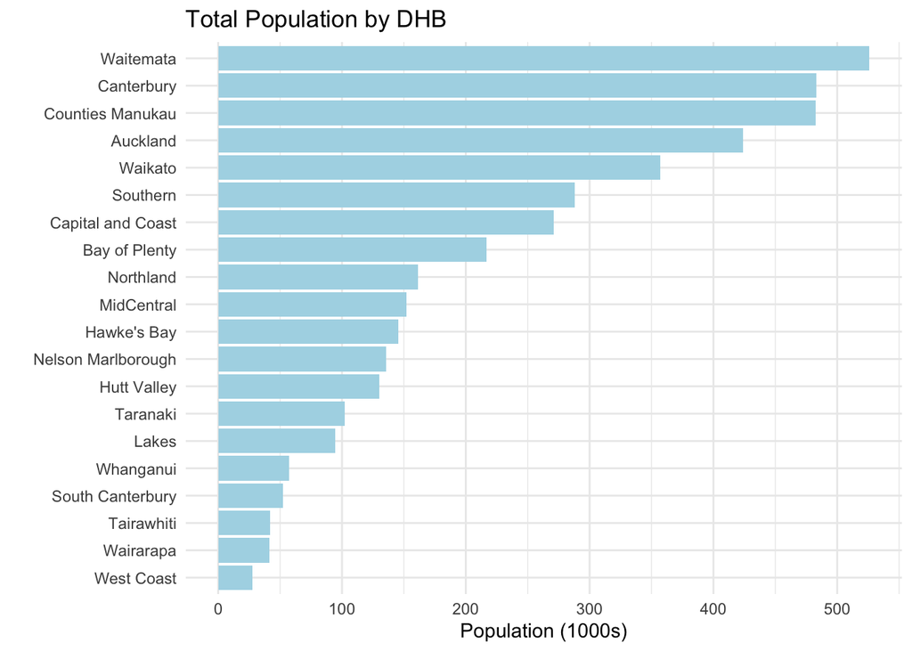

### Ethnic Group

MOH report data by Ethnic group and age group, and both factors have been commented on in the media. The chart belows below show the Ethnic group split reported by DHB, ordered by total population.

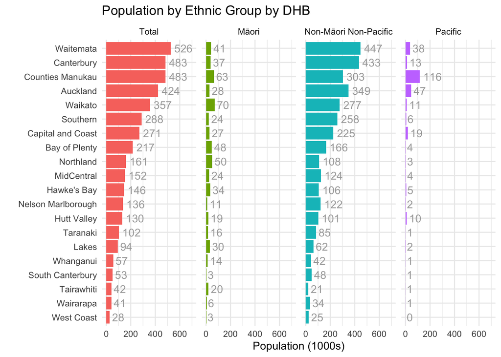

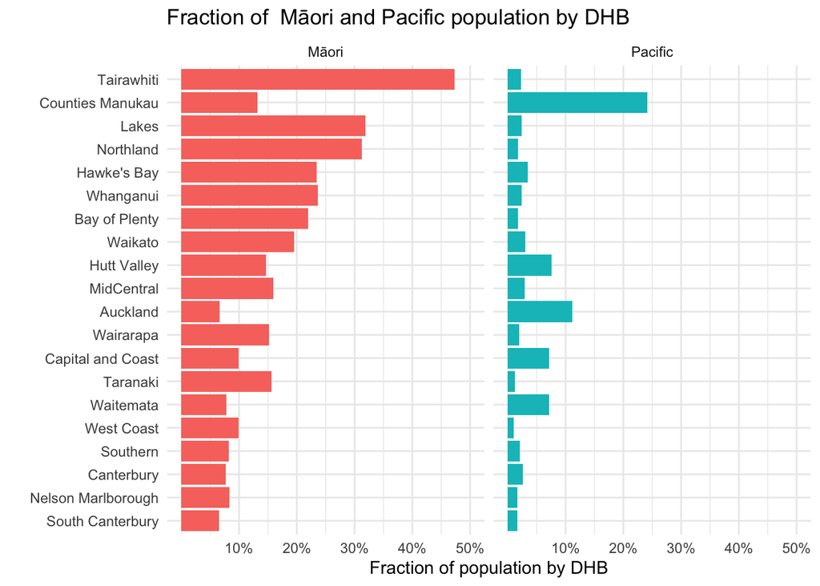

### Age Group

The vaccination target is two doses of pfizer vaccine for 90% of the eligible population in each DHB. At present, the ineligible popualtion is people with medical exemptions and children under the age of 12. The population data accessed here does not include ondere 12s. That is, the sum for each DHB over all age and ethnic groups is the vaccine-eligible populaiton (apart from small numbers of exemptions).

Another age realted factos is the initial roll out to more vulnerable people, including those over 65 years of age. This should be kept in mind when comoparing vaccination uptake, as some DHBs have older (or younger) poplautions than others.

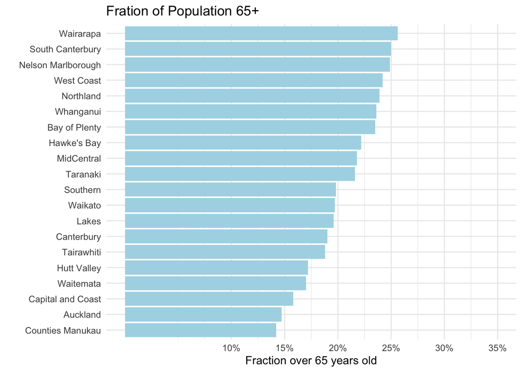

## Uptake Rates

### Overall NZ Uptake Rate

Let’s now look at the vaccination uptake rates, recorded as first or second dose counts per week.

| week | dose | ethnicgroup | agegroup | DHB | count | popsegment |
| --- | --- | --- | --- | --- | --- | --- |
| 2021-10-24 | 1 | Pacific | 65+ | Whanganui | 1 | 106 |
| 2021-10-24 | 2 | Pacific | 65+ | Whanganui | 1 | 106 |
| 2021-10-31 | 1 | Pacific | 65+ | Whanganui | 1 | 106 |
| 2021-10-31 | 2 | Pacific | 65+ | Whanganui | 1 | 106 |
| 2021-11-07 | 1 | Pacific | 65+ | Whanganui | 1 | 106 |
| 2021-11-07 | 2 | Pacific | 65+ | Whanganui | 1 | 106 |

| ethnicgroup | agegroup | DHB | popsegment |
| --- | --- | --- | --- |
| Māori | 12-19 | Auckland | 4639 |
| Māori | 20-34 | Auckland | 9475 |
| Māori | 35-49 | Auckland | 6355 |
| Māori | 50-64 | Auckland | 5221 |
| Māori | 65+ | Auckland | 2102 |
| Non-Māori Non-Pacific | 12-19 | Auckland | 31584 |

```
[1] "week"        "dose"        "ethnicgroup" "agegroup"    "DHB"
[6] "count"       "popsegment"
```

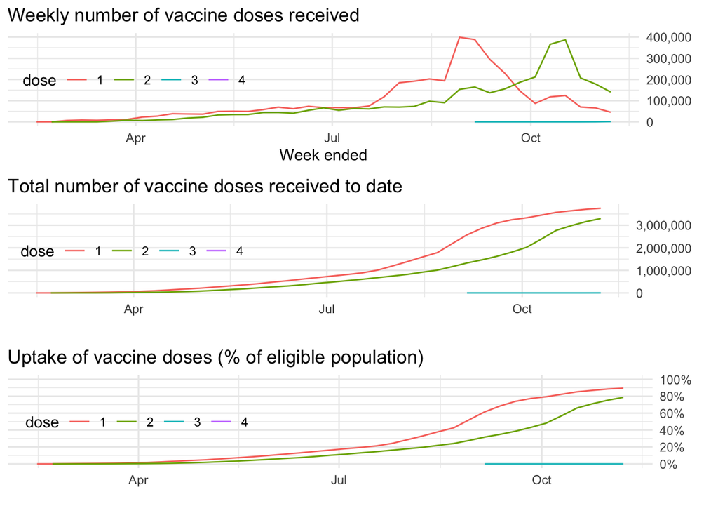

### Uptake Rate by DHB

Let’s now look at the vaccination uptake rates, recorded as first or second dose counts per week.

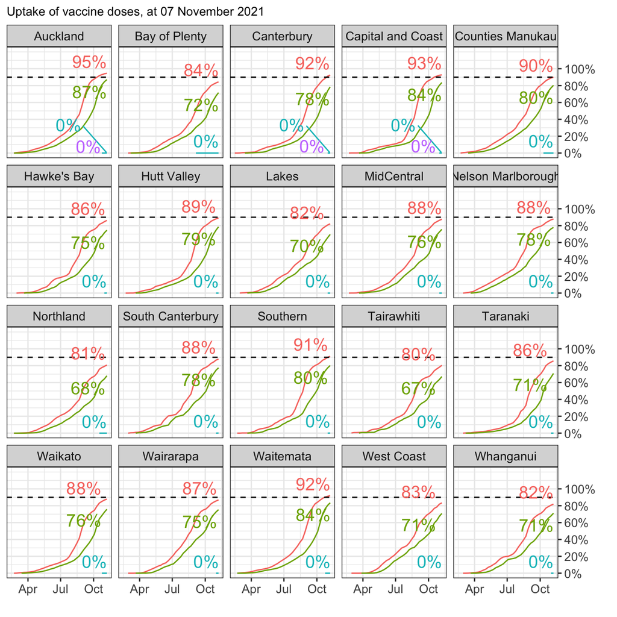

### NZ Overall Uptake

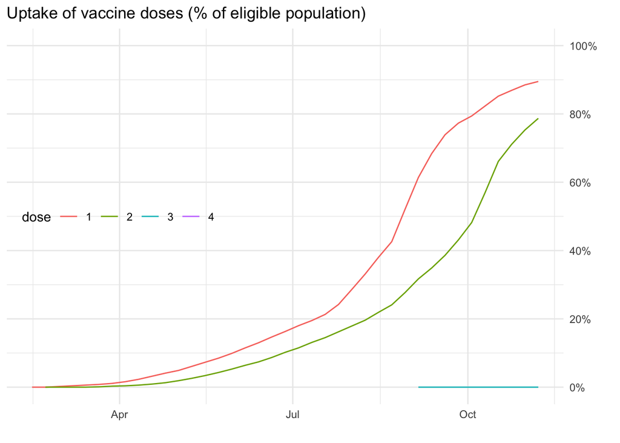

```r
p_v_nz_uptake2 <- ggplot(data = v_nz, aes(x = week, y = uptake, color = dose)) +
  geom_line() +
  scale_x_date() +
  scale_y_continuous(position = "right",
                     label = scales::percent_format(accuracy = 1),
                     limits = c(0,1),
                     breaks = seq(0,1,0.2)) +
  labs(y = "",
       x = "") +
  ggtitle("Uptake of vaccine doses (% of eligible population)") +
  theme_minimal() +
  theme(legend.position=c(0.2,0.5),
        legend.direction = "horizontal")

# m <- glm(surv ~ size, family = binomial, data = v_nz)
# #…and extract fitted values using broom::augment()
#
# plot_df <- augment(m, type.predict = "response")
# head(plot_df)

grid.arrange(p_v_nz_uptake2)
```

### Correlations between uptake and other factors